# Pandas Package - Part II

# Filtering

```python
df.query("rating > 4.9999")
```

|  | rating | review_count | isbn | booktype | author_url | year | genre_urls | dir | rating_count | name |
| --- | --- | --- | --- | --- | --- | --- | --- | --- | --- | --- |
| 1718 | 5.0 | 28 | NaN | good_reads:book | https://www.goodreads.com/author/show/6467808.... | 2014.0 | /genres/poetry\|/genres/childrens | dir18/22204746-an-elephant-is-on-my-house.html | 64 | An Elephant Is On My House |
| 2145 | 5.0 | 3 | 1300589469 | good_reads:book | https://www.goodreads.com/author/show/6906561.... | 2012.0 | NaN | dir22/17287259-a-book-about-absolutely-nothing... | 63 | A Book About Absolutely Nothing. |
| 2903 | 5.0 | 0 | 0983002282 | good_reads:book | https://www.goodreads.com/author/show/6589034.... | 2012.0 | NaN | dir30/17608096-obscured-darkness.html | 8 | Obscured Darkness (Family Secrets #2) |
| 2909 | 5.0 | 0 | 0983002215 | good_reads:book | https://www.goodreads.com/author/show/6589034.... | 2011.0 | NaN | dir30/16200303-family-secrets.html | 9 | Family Secrets |
| 4473 | 5.0 | 0 | NaN | good_reads:book | https://www.goodreads.com/author/show/6896621.... | 2012.0 | NaN | dir45/17259227-patience-s-love.html | 7 | Patience's Love |
| 5564 | 5.0 | 9 | NaN | good_reads:book | https://www.goodreads.com/author/show/7738947.... | 2014.0 | /genres/romance\|/genres/new-adult | dir56/21902777-untainted.html | 14 | Untainted (Photographer Trilogy, #3) |
| 5692 | 5.0 | 0 | NaN | good_reads:book | https://www.goodreads.com/author/show/5989528.... | 2012.0 | NaN | dir57/14288412-abstraction-in-theory---laws-of... | 6 | Abstraction In Theory - Laws Of Physical Trans... |

```python
df[df.year < 0]
```

|  | rating | review_count | isbn | booktype | author_url | year | genre_urls | dir | rating_count | name |
| --- | --- | --- | --- | --- | --- | --- | --- | --- | --- | --- |
| 47 | 3.68 | 5785 | 0143039954 | good_reads:book | https://www.goodreads.com/author/show/903.Homer | -800.0 | /genres/classics\|/genres/fiction\|/genres/poetr... | dir01/1381.The_Odyssey.html | 560248 | The Odyssey |
| 246 | 4.01 | 365 | 0147712556 | good_reads:book | https://www.goodreads.com/author/show/903.Homer | -800.0 | /genres/classics\|/genres/fantasy\|/genres/mytho... | dir03/1375.The_Iliad_The_Odyssey.html | 35123 | The Iliad/The Odyssey |
| 455 | 3.85 | 1499 | 0140449140 | good_reads:book | https://www.goodreads.com/author/show/879.Plato | -380.0 | /genres/philosophy\|/genres/classics\|/genres/no... | dir05/30289.The_Republic.html | 82022 | The Republic |
| 596 | 3.77 | 1240 | 0679729526 | good_reads:book | https://www.goodreads.com/author/show/919.Virgil | -29.0 | /genres/classics\|/genres/poetry\|/genres/fictio... | dir06/12914.The_Aeneid.html | 60308 | The Aeneid |
| 629 | 3.64 | 1231 | 1580495931 | good_reads:book | https://www.goodreads.com/author/show/1002.Sop... | -429.0 | /genres/classics\|/genres/plays\|/genres/drama\|/... | dir07/1554.Oedipus_Rex.html | 93192 | Oedipus Rex |
| 674 | 3.92 | 3559 | 1590302257 | good_reads:book | https://www.goodreads.com/author/show/1771.Sun... | -512.0 | /genres/non-fiction\|/genres/politics\|/genres/c... | dir07/10534.The_Art_of_War.html | 114619 | The Art of War |
| 746 | 4.06 | 1087 | 0140449183 | good_reads:book | https://www.goodreads.com/author/show/5158478.... | -500.0 | /genres/classics\|/genres/spirituality\|/genres/... | dir08/99944.The_Bhagavad_Gita.html | 31634 | The Bhagavad Gita |
| 777 | 3.52 | 1038 | 1580493882 | good_reads:book | https://www.goodreads.com/author/show/1002.Sop... | -442.0 | /genres/drama\|/genres/fiction\|/genres/classics... | dir08/7728.Antigone.html | 49084 | Antigone |
| 1233 | 3.94 | 704 | 015602764X | good_reads:book | https://www.goodreads.com/author/show/1002.Sop... | -400.0 | /genres/classics\|/genres/plays\|/genres/drama\|/... | dir13/1540.The_Oedipus_Cycle.html | 36008 | The Oedipus Cycle |
| 1397 | 4.03 | 890 | 0192840509 | good_reads:book | https://www.goodreads.com/author/show/12452.Aesop | -560.0 | /genres/classics\|/genres/childrens\|/genres/lit... | dir14/21348.Aesop_s_Fables.html | 71259 | Aesop's Fables |
| 1398 | 3.60 | 1644 | 0141026286 | good_reads:book | https://www.goodreads.com/author/show/5158478.... | -1500.0 | /genres/religion\|/genres/literature\|/genres/an... | dir14/19351.The_Epic_of_Gilgamesh.html | 42026 | The Epic of Gilgamesh |
| 1428 | 3.80 | 539 | 0486275485 | good_reads:book | https://www.goodreads.com/author/show/973.Euri... | -431.0 | /genres/classics\|/genres/plays\|/genres/drama\|/... | dir15/752900.Medea.html | 29858 | Medea |
| 1815 | 3.96 | 493 | 0140443339 | good_reads:book | https://www.goodreads.com/author/show/990.Aesc... | -458.0 | /genres/classics\|/genres/plays\|/genres/drama\|/... | dir19/1519.The_Oresteia.html | 18729 | The Oresteia |
| 1882 | 4.02 | 377 | 0872205541 | good_reads:book | https://www.goodreads.com/author/show/879.Plato | -400.0 | /genres/philosophy\|/genres/classics\|/genres/no... | dir19/22632.The_Trial_and_Death_of_Socrates.html | 18712 | The Trial and Death of Socrates |
| 2078 | 3.84 | 399 | 0140440399 | good_reads:book | https://www.goodreads.com/author/show/957.Thuc... | -411.0 | /genres/history\|/genres/classics\|/genres/non-f... | dir21/261243.The_History_of_the_Peloponnesian_... | 17212 | The History of the Peloponnesian War |
| 2527 | 3.94 | 506 | 0140449086 | good_reads:book | https://www.goodreads.com/author/show/901.Hero... | -440.0 | /genres/history\|/genres/classics\|/genres/non-f... | dir26/1362.The_Histories.html | 20570 | The Histories |
| 3133 | 4.30 | 131 | 0872203492 | good_reads:book | https://www.goodreads.com/author/show/879.Plato | -400.0 | /genres/philosophy\|/genres/classics\|/genres/no... | dir32/9462.Complete_Works.html | 7454 | Complete Works |
| 3274 | 3.88 | 411 | 0140449493 | good_reads:book | https://www.goodreads.com/author/show/2192.Ari... | -350.0 | /genres/philosophy\|/genres/classics\|/genres/no... | dir33/19068.The_Nicomachean_Ethics.html | 16534 | The Nicomachean Ethics |
| 3757 | 3.82 | 364 | 0872206033 | good_reads:book | https://www.goodreads.com/author/show/1011.Ari... | -411.0 | /genres/plays\|/genres/classics\|/genres/drama\|/... | dir38/1591.Lysistrata.html | 18070 | Lysistrata |
| 4402 | 3.99 | 516 | 0140449272 | good_reads:book | https://www.goodreads.com/author/show/879.Plato | -370.0 | /genres/non-fiction\|/genres/classics\|/genres/p... | dir45/81779.The_Symposium.html | 18457 | The Symposium |
| 4475 | 4.11 | 281 | 0865163480 | good_reads:book | https://www.goodreads.com/author/show/879.Plato | -390.0 | /genres/philosophy\|/genres/classics\|/genres/no... | dir45/73945.Apology.html | 11478 | Apology |
| 5367 | 4.07 | 133 | 0872206335 | good_reads:book | https://www.goodreads.com/author/show/879.Plato | -360.0 | /genres/philosophy\|/genres/classics\|/genres/no... | dir54/30292.Five_Dialogues.html | 9964 | Five Dialogues |

If you want to combine these conditions, use the second form and put '()' brackets around each condition. The query uses a boolean AND. Each condition ceates a mask of trues and falses.

```python
df[(df.year < 0) & (df.rating > 4)]#there are none greater than 4.5!
```

|  | rating | review_count | isbn | booktype | author_url | year | genre_urls | dir | rating_count | name |
| --- | --- | --- | --- | --- | --- | --- | --- | --- | --- | --- |
| 246 | 4.01 | 365 | 0147712556 | good_reads:book | https://www.goodreads.com/author/show/903.Homer | -800.0 | /genres/classics\|/genres/fantasy\|/genres/mytho... | dir03/1375.The_Iliad_The_Odyssey.html | 35123 | The Iliad/The Odyssey |
| 746 | 4.06 | 1087 | 0140449183 | good_reads:book | https://www.goodreads.com/author/show/5158478.... | -500.0 | /genres/classics\|/genres/spirituality\|/genres/... | dir08/99944.The_Bhagavad_Gita.html | 31634 | The Bhagavad Gita |
| 1397 | 4.03 | 890 | 0192840509 | good_reads:book | https://www.goodreads.com/author/show/12452.Aesop | -560.0 | /genres/classics\|/genres/childrens\|/genres/lit... | dir14/21348.Aesop_s_Fables.html | 71259 | Aesop's Fables |
| 1882 | 4.02 | 377 | 0872205541 | good_reads:book | https://www.goodreads.com/author/show/879.Plato | -400.0 | /genres/philosophy\|/genres/classics\|/genres/no... | dir19/22632.The_Trial_and_Death_of_Socrates.html | 18712 | The Trial and Death of Socrates |
| 3133 | 4.30 | 131 | 0872203492 | good_reads:book | https://www.goodreads.com/author/show/879.Plato | -400.0 | /genres/philosophy\|/genres/classics\|/genres/no... | dir32/9462.Complete_Works.html | 7454 | Complete Works |
| 4475 | 4.11 | 281 | 0865163480 | good_reads:book | https://www.goodreads.com/author/show/879.Plato | -390.0 | /genres/philosophy\|/genres/classics\|/genres/no... | dir45/73945.Apology.html | 11478 | Apology |
| 5367 | 4.07 | 133 | 0872206335 | good_reads:book | https://www.goodreads.com/author/show/879.Plato | -360.0 | /genres/philosophy\|/genres/classics\|/genres/no... | dir54/30292.Five_Dialogues.html | 9964 | Five Dialogues |

```python
df[(df.year < 0) & (df.rating > 4.0)]
```

|  | rating | review_count | isbn | booktype | author_url | year | genre_urls | dir | rating_count | name |
| --- | --- | --- | --- | --- | --- | --- | --- | --- | --- | --- |
| 246 | 4.01 | 365 | 0147712556 | good_reads:book | https://www.goodreads.com/author/show/903.Homer | -800.0 | /genres/classics\|/genres/fantasy\|/genres/mytho... | dir03/1375.The_Iliad_The_Odyssey.html | 35123 | The Iliad/The Odyssey |
| 746 | 4.06 | 1087 | 0140449183 | good_reads:book | https://www.goodreads.com/author/show/5158478.... | -500.0 | /genres/classics\|/genres/spirituality\|/genres/... | dir08/99944.The_Bhagavad_Gita.html | 31634 | The Bhagavad Gita |
| 1397 | 4.03 | 890 | 0192840509 | good_reads:book | https://www.goodreads.com/author/show/12452.Aesop | -560.0 | /genres/classics\|/genres/childrens\|/genres/lit... | dir14/21348.Aesop_s_Fables.html | 71259 | Aesop's Fables |
| 1882 | 4.02 | 377 | 0872205541 | good_reads:book | https://www.goodreads.com/author/show/879.Plato | -400.0 | /genres/philosophy\|/genres/classics\|/genres/no... | dir19/22632.The_Trial_and_Death_of_Socrates.html | 18712 | The Trial and Death of Socrates |
| 3133 | 4.30 | 131 | 0872203492 | good_reads:book | https://www.goodreads.com/author/show/879.Plato | -400.0 | /genres/philosophy\|/genres/classics\|/genres/no... | dir32/9462.Complete_Works.html | 7454 | Complete Works |
| 4475 | 4.11 | 281 | 0865163480 | good_reads:book | https://www.goodreads.com/author/show/879.Plato | -390.0 | /genres/philosophy\|/genres/classics\|/genres/no... | dir45/73945.Apology.html | 11478 | Apology |
| 5367 | 4.07 | 133 | 0872206335 | good_reads:book | https://www.goodreads.com/author/show/879.Plato | -360.0 | /genres/philosophy\|/genres/classics\|/genres/no... | dir54/30292.Five_Dialogues.html | 9964 | Five Dialogues |

# Cleaning

We first check the datatypes. Notice that review_count, rating_count are of type object (which means they are either strings or Pandas couldnt figure what they are), while year is a float.

```python
df.dtypes
```

```
rating          float64
review_count     object
isbn             object
booktype         object
author_url       object
year            float64
genre_urls       object
dir              object
rating_count     object
name             object
dtype: object
```

```python
df['rating_count']=df.rating_count.astype(int)
df['review_count']=df.review_count.astype(int)
df['year']=df.year.astype(int)
```

[output not shown]

## Ooops we got an error. Something is not right. Its trying to convert some python datatype: None into an int. This usually means data was missing. Was it?

```python
df=pd.read_csv("/Users/rajan/Documents/Online Training/all.csv", header=None,
               names=["rating", 'review_count', 'isbn', 'booktype','author_url', 'year',
                      'genre_urls', 'dir','rating_count', 'name'])
```

```python
df[df.year.isnull()] ## checking if year is NULL
```

|  | rating | review_count | isbn | booktype | author_url | year | genre_urls | dir | rating_count | name |
| --- | --- | --- | --- | --- | --- | --- | --- | --- | --- | --- |
| 2442 | 4.23 | 526 | NaN | good_reads:book | https://www.goodreads.com/author/show/623606.A... | NaN | /genres/religion\|/genres/islam\|/genres/non-fic... | dir25/1301625.La_Tahzan.html | 4134 | La Tahzan |
| 2869 | 4.61 | 2 | NaN | good_reads:book | https://www.goodreads.com/author/show/8182217.... | NaN | NaN | dir29/22031070-my-death-experiences---a-preach... | 23 | My Death Experiences - A Preacherâs 18 Apoca... |
| 3643 | NaN | None | None | None | None | NaN | NaN | dir37/9658936-harry-potter.html | None | None |
| 5282 | NaN | None | None | None | None | NaN | NaN | dir53/113138.The_Winner.html | None | None |
| 5572 | 3.71 | 35 | 8423336603 | good_reads:book | https://www.goodreads.com/author/show/285658.E... | NaN | /genres/fiction | dir56/890680._rase_una_vez_el_amor_pero_tuve_q... | 403 | Ãrase una vez el amor pero tuve que matarlo. ... |
| 5658 | 4.32 | 44 | NaN | good_reads:book | https://www.goodreads.com/author/show/25307.Ro... | NaN | /genres/fantasy\|/genres/fantasy\|/genres/epic-f... | dir57/5533041-assassin-s-apprentice-royal-assa... | 3850 | Assassin's Apprentice / Royal Assassin (Farsee... |
| 5683 | 4.56 | 204 | NaN | good_reads:book | https://www.goodreads.com/author/show/3097905.... | NaN | /genres/fantasy\|/genres/young-adult\|/genres/ro... | dir57/12474623-tiger-s-dream.html | 895 | Tiger's Dream (The Tiger Saga, #5) |

Let's get rid of data where we dont have the year'

```python
df = df[df.year.notnull()]
```

```python
df.shape
```

```
(5993, 10)
```

```python
df.dtypes
```

```
rating          float64
review_count     object
isbn             object
booktype         object
author_url       object
year            float64
genre_urls       object
dir              object
rating_count     object
name             object
dtype: object
```

##### We got rid of 7 rows. Let's try the conversion again

```python
df['rating_count']=df.rating_count.astype(int)
df['review_count']=df.review_count.astype(int)
df['year']=df.year.astype(int)
```

```python
df.dtypes
```

```
rating          float64
review_count      int64
isbn             object
booktype         object
author_url       object
year              int64
genre_urls       object
dir              object
rating_count      int64
name             object
dtype: object
```

```python
###### much cleaner now.
```

# Missing Data

```python
#When and Why Is Data Missed?
#Let us consider an online survey for a product. Many a times, people do not share all
#the information related to them. Few people share their experience, but not how long they are using the product;
#few people share how long they are using the product, their experience but not their contact information.
#Thus, in some or the other way a part of data is always missing, and this is very common in real time.

#Let us now see how we can handle missing values (say NA or NaN) using Pandas.
```

```python
df = pd.DataFrame(np.random.randn(5, 3), index=['a', 'c', 'e', 'f',
'h'],columns=['one', 'two', 'three'])

df = df.reindex(['a', 'b', 'c', 'd', 'e', 'f', 'g', 'h'])
```

```python
df
```

|  | one | two | three |
| --- | --- | --- | --- |
| a | 2.260968 | 0.561215 | 0.682905 |
| b | NaN | NaN | NaN |
| c | 0.182184 | -0.153131 | -0.803791 |
| d | NaN | NaN | NaN |
| e | -1.219553 | 0.762446 | 0.587075 |
| f | 0.009953 | -0.810619 | 0.524110 |
| g | NaN | NaN | NaN |
| h | 1.249150 | -0.731923 | -0.110459 |

```python
df = pd.DataFrame(np.random.randn(3, 3), index=['a', 'c', 'e'],columns=['one',
'two', 'three'])
df = df.reindex(['a', 'b', 'c'])
```

```python
df
```

|  | one | two | three |
| --- | --- | --- | --- |
| a | -0.975137 | 1.649897 | -1.476685 |
| b | NaN | NaN | NaN |
| c | 0.561665 | 0.257183 | 0.247343 |

```python
print ("NaN replaced with '0':")
df.fillna(0)
```

```
NaN replaced with '0':
```

|  | one | two | three |
| --- | --- | --- | --- |
| a | -0.975137 | 1.649897 | -1.476685 |
| b | 0.000000 | 0.000000 | 0.000000 |
| c | 0.561665 | 0.257183 | 0.247343 |

```python
print ("NaN replaced with '0':")   ### if fillna(0) does not work use fillna(0, inplace=True)
df.fillna(0,inplace = True)
```

```
NaN replaced with '0':
```

# Drop missing values

```python
#If you want to simply exclude the missing values, then use the dropna function along with the axis argument.
#By default, axis=0, i.e., along row, which means that if any value within a row is NA
#then the whole row is excluded.
```

```python
df = pd.DataFrame(np.random.randn(5, 3), index=['a', 'c', 'e', 'f',
'h'],columns=['one', 'two', 'three'])

df = df.reindex(['a', 'b', 'c', 'd', 'e', 'f', 'g', 'h'])
```

```python
df
```

[output not shown]

```python
df.dropna()
```

[output not shown]

```python
df = pd.DataFrame(np.random.randn(5, 3), index=['a', 'c', 'e', 'f',
'h'],columns=['one', 'two', 'three'])
print("Initial data frame")
#print(df)

df = df.reindex(['a', 'b', 'c', 'd', 'e', 'f', 'g', 'h'])
print("After reindex")
print(df)
print (df.dropna(axis=0))
```

```
Initial data frame
After reindex
        one       two     three
a  0.977001 -0.998154  1.167333
b       NaN       NaN       NaN
c -0.468458 -0.746522 -0.621260
d       NaN       NaN       NaN
e -0.131632 -0.880111  0.430024
f -0.242688  0.852460 -0.239853
g       NaN       NaN       NaN
h -0.038659  0.093036  2.140250
        one       two     three
a  0.977001 -0.998154  1.167333
c -0.468458 -0.746522 -0.621260
e -0.131632 -0.880111  0.430024
f -0.242688  0.852460 -0.239853
h -0.038659  0.093036  2.140250
```

```python
print (df.dropna(axis=1)) ## All columns with NaN values were dropped
```

[output not shown]

```python
print (df.dropna(axis=0))
```

[output not shown]

## Replacing missing or generic values

```python
df = pd.DataFrame({'one':[10,20,30,40,50,2000],
'two':[1000,0,30,40,50,60]})
```

```python
df
```

|  | one | two |
| --- | --- | --- |
| 0 | 10 | 1000 |
| 1 | 20 | 0 |
| 2 | 30 | 30 |
| 3 | 40 | 40 |
| 4 | 50 | 50 |
| 5 | 2000 | 60 |

```python
print(df.replace({1000:10,2000:60}))
```

```
   one  two
0   10   10
1   20    0
2   30   30
3   40   40
4   50   50
5   60   60
```

```python
df
```

|  | one | two |
| --- | --- | --- |
| 0 | 10 | 1000 |
| 1 | 20 | 0 |
| 2 | 30 | 30 |
| 3 | 40 | 40 |
| 4 | 50 | 50 |
| 5 | 2000 | 60 |

# Visualizing

Pandas has handy built in visualization.

```python
import pandas as pd
df=pd.read_csv("/Users/rajan/Documents/Online Training/all.csv", header=None,
               names=["rating", 'review_count', 'isbn', 'booktype','author_url', 'year', 'genre_urls',
                      'dir','rating_count', 'name'])
```

```python
import matplotlib
import pandas as pd
import numpy as np
```

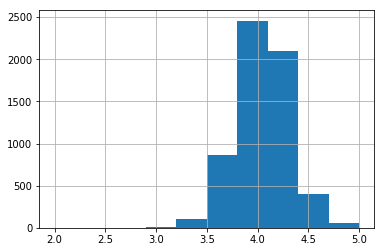

```python
df.rating.hist() ### histogram for the ratings
```

```python
df.review_count.hist(bins=np.arange(0, 40000, 400))
```

[output not shown]

```python
df.review_count.hist(bins=100)
plt.xscale("log");
```

[output not shown]